# Activitat 1

Ignasi Elgström Puyuelo

2024-10-26

## Exercici 1

1.1 Primer llegim l’arxiu CSV considerant les següents consideracions:

- El separador de les variables serà el caràcter ‘;’
- Tractarem els nombres decimals amb el caràcter ‘.’
- Tots els camps que no estiguin informats els establim a NA

```r
file <- read.csv("gem01.csv",header = FALSE, stringsAsFactors = TRUE, sep = ";",dec = ".", na.strings=c(""))
```

1.2 Un cop això, podem mostrar el nom de les variables, així com la seva descripció a partir de les dades originals:

```r
description <- sapply(file[1,],function(x) str_replace_all(x,'[.]',' ')) #Creem llista de descripcion
name <- unlist(file[2,]) #Creem llista de noms
df <- data.frame(Name = name,Description=description)
rownames(df) <- NULL #Descartem la indexació per defecte
kbl(df) %>% #Dibixem la taula
  kable_paper(full_width = F) %>%
  column_spec(1, bold = T, border_right = T) %>%
  column_spec(2)%>%
  scroll_box( height = "350px")
```

| Name | Description |
| --- | --- |
| code | X |
| economy | X 1 |
| year | X 2 |
| Perceived opportunities | Percentage of 18 64 population who see good opportunities to start a firm in the area where they live |
| Perceived capabilities | Percentage of 18 64 population who believe they have the required skills and knowledge to start a business |
| Fear of failure rate * | Percentage of the 18 64 population who agree that they see good opportunities but would not start a business for fear it might fail NOTE this is a percentage of those seeing good opportunities and not… |
| Entrepreneurial intentions | Percentage of 18 64 population individuals involved in any stage of entrepreneurial activity excluded who are latent entrepreneurs and who intend to start a business within three years |
| Total early-stage Entrepreneurial Activity (TEA) | Percentage of 18 64 population who are either a nascent entrepreneur or owner manager of a new business |
| Established Business Ownership | Percentage of 18 64 population who are currently an owner manager of an established business i e owning and managing a running business that has paid salaries wages or any other payments to the owners… |
| Entrepreneurial Employee Activity | Rate of involvement of employees in entrepreneurial activities such as developing or launching new goods or services or setting up a new business unit a new establishment or subsidiary |
| Motivational Index | Percentage of those involved in TEA that are improvement driven opportunity motivated divided by the percentage of TEA that is necessity motivated |
| Female/Male TEA | Percentage of female 18 64 population who are either a nascent entrepreneur or owner manager of a new business divided by the equivalent percentage for their male counterparts |
| Female/Male Opportunity-Driven TEA | Percentage of those females involved in TEA who i claim to be driven by opportunity as opposed to finding no other option for work and ii who indicate the main driver for being involved in this opport… |
| High Job Creation Expectation | Percentage of those involved in TEA who expect to create 6 or more jobs in 5 years |
| Innovation | Percentage of those involved in TEA who indicate that their product or service is new to at least some customers AND that few no businesses offer the same product |
| Business Services Sector | Percentage of those involved in TEA in the Business Services sector Information and Communication Financial Intermediation and Real Estate Professional Services or Administrative Services as defined b… |
| High Status to Successful Entrepreneurs | Percentage of 18 64 population who agree with the statement that in their country successful entrepreneurs receive high status |
| Entrepreneurship as a Good Career Choice | Percentage of 18 64 population who agree with the statement that in their country most people consider starting a business as a desirable career choice |

1.3 Eliminem la primera fila i canviem de nom cada identificador quedant-nos una taula com aquesta:

```r
colnames(file) <- c('Code','Economy','Year','OPP','PC','FAIL','EI','TEA','OWN','EMPL','MOT','FMTEA','FMOD','JOB','INNOV','BSER','STAT','CHOI') #Establim el nom de les columnes
file <- file[-c(1,2),] #Eliminem les files que no ens interessen
file <- type.convert(file, as.is=TRUE) #Tornem a fer que el sistema infereixi nous tipus de dades per columna
rownames(file) <- NULL #Ens desfem de la indexació automàtica
head(file,n=5) %>% #Dibuixem la taula
  kbl() %>%
  kable_paper("hover")
```

| Code | Economy | Year | OPP | PC | FAIL | EI | TEA | OWN | EMPL | MOT | FMTEA | FMOD | JOB | INNOV | BSER | STAT | CHOI |
| --- | --- | --- | --- | --- | --- | --- | --- | --- | --- | --- | --- | --- | --- | --- | --- | --- | --- |
| 1 | United States | 2023 | 53.81 | 48.99 | 44.55 | 12.09 | 14.71 | 6.74 | NA | NA | 0.84 | NA | 28.80 | NA | 20.42 | 78.94 | 79.21 |
| 27 | South Africa | 2023 | 64.10 | 69.21 | 59.51 | 7.45 | 11.11 | 5.92 | NA | NA | 0.76 | NA | 21.42 | NA | 3.57 | 85.51 | 78.46 |
| 30 | Greece | 2023 | 45.29 | 53.76 | 53.16 | 9.10 | 6.74 | 14.70 | NA | NA | 0.79 | NA | 12.12 | NA | 22.53 | 69.76 | 72.90 |
| 31 | Netherlands | 2023 | 67.37 | 46.01 | 40.29 | 16.02 | 13.69 | 6.92 | NA | NA | 0.80 | NA | 15.13 | NA | 23.65 | NA | NA |
| 33 | France | 2023 | 50.86 | 49.51 | 40.08 | 13.41 | 10.75 | 4.56 | NA | NA | 0.72 | NA | 23.17 | NA | 32.58 | 51.76 | 65.41 |

## Exercici 2

2.1 Si fem una revisió de tot el llistat de països a simple vista, podem veure algunes inconsistències:

```r
file["Economy"]%>%
  unique()%>%
  unlist()%>%
  cat(sep=", ")
```

```
## United States, South Africa, Greece, Netherlands, France, Spain, Hungary, Italy, Romania, Switzerland, United Kingdom, Sweden, Norway, Poland, Germany, Mexico, Brazil, Chile, Colombia, Venezuela, Thailand, South Korea, China, India, Iran, Canada, Morocco, Luxembourg, Cyprus, Lithuania, Latvia, Es…
```

Veiem que hi ha inconsistències, no tots els països estan seguint el mateix format de majúscules, per tant, farem una transformació perquè tots els països ho siguin.

```r
file$Economy <- sapply(file$Economy, str_to_title) #Apliquem els canvis de fer els noms de paisos majúscula.
```

Fem després agrupacions, agrupant per l’any màxim registrat (max_year), l’any mínim registrat (min_year) i els diferents nombres d’anys registrats (registered_years):

```r
file_gb <- file %>%
  group_by(Economy) %>% #Agrupem per pais
  summarise(min_year = min(Year),max_year = max(Year), registered_years = n_distinct(Year))
  #Fem servir funcions agrupadores per deduir les dades

file_gb %>% #Dibuixem la taula per pantalla
  mutate(index = row_number()) %>% #Afegim un index a la taula
  select(index, everything()) %>% #Fiquem l'index el principi
  kbl() %>%
  kable_paper(bootstrap_options = "striped", full_width = F)%>%
  scroll_box( height = "300px")
```

| index | Economy | min_year | max_year | registered_years |
| --- | --- | --- | --- | --- |
| 1 | Algeria | 2009 | 2013 | 4 |
| 2 | Angola | 2008 | 2020 | 7 |
| 3 | Argentin | 2001 | 2001 | 1 |
| 4 | Argentina | 2002 | 2018 | 17 |
| 5 | Armenia | 2019 | 2019 | 1 |
| 6 | Australia | 2001 | 2019 | 13 |
| 7 | Austria | 2005 | 2022 | 8 |
| 8 | Bangladesh | 2011 | 2011 | 1 |
| 9 | Barbados | 2011 | 2015 | 5 |
| 10 | Belarus | 2019 | 2021 | 2 |
| 11 | Belgium | 2001 | 2015 | 15 |
| 12 | Belize | 2014 | 2016 | 2 |
| 13 | Bolivia | 2008 | 2014 | 3 |
| 14 | Bosnia And Herzegovina | 2008 | 2017 | 8 |
| 15 | Botswana | 2012 | 2015 | 4 |
| 16 | Brazil | 2001 | 2023 | 23 |
| 17 | Bulgaria | 2015 | 2018 | 4 |
| 18 | Burkina Faso | 2014 | 2020 | 4 |
| 19 | Cameroon | 2014 | 2016 | 3 |
| 20 | Canada | 2001 | 2023 | 17 |
| 21 | Chile | 2002 | 2023 | 21 |
| 22 | China | 2002 | 2023 | 18 |
| 23 | Colombia | 2006 | 2023 | 18 |
| 24 | Costa Rica | 2010 | 2014 | 3 |
| 25 | Croatia | 2002 | 2023 | 22 |
| 26 | Cyprus | 2016 | 2023 | 8 |
| 27 | Czech Republic | 2006 | 2013 | 3 |
| 28 | Denmark | 2001 | 2014 | 13 |
| 29 | Dominican Republic | 2007 | 2021 | 4 |
| 30 | Ecuador | 2004 | 2023 | 12 |

[output cut: 88 more lines]

## Exercici 3

3.1 En aquest primer pas, no hem de fer cap cerca de si hi ha valors buits, ja que ho hem explicitat a l’importar el CSV, que els valors buits es consideressin NA. Mostrem, aleshores els valors NA per columna:

```r
na_count <- sapply(file, function(x) sum(is.na(x))) #Es conten quants NA hi ha per columna

na_count%>%
  t()%>% #Transformem les dades per mostrar-les millor
  as.data.frame()%>%
  kbl()%>%
  kable_styling()
```

| Code | Economy | Year | OPP | PC | FAIL | EI | TEA | OWN | EMPL | MOT | FMTEA | FMOD | JOB | INNOV | BSER | STAT | CHOI |
| --- | --- | --- | --- | --- | --- | --- | --- | --- | --- | --- | --- | --- | --- | --- | --- | --- | --- |
| 0 | 0 | 0 | 0 | 0 | 1 | 28 | 0 | 1 | 580 | 580 | 0 | 761 | 3 | 639 | 38 | 133 | 135 |

També mostrem quins són els rangs de les variables numèriques (màxims i mínims) per cada variable:

```r
max_val <- sapply(file[,4:ncol(file)], function(x) max(x, na.rm=TRUE))#Calculem els maxim per columna
min_val <- sapply(file[,4:ncol(file)], function(x) min(x, na.rm=TRUE))#Calculem els minims per columna
df_result <- data.frame(Max=max_val, Min=min_val)
df_result%>%
  t()%>% #Transformem les dades per mostrar-les millor
  as.data.frame()%>%
  kbl()%>%
  kable_styling()
```

|  | OPP | PC | FAIL | EI | TEA | OWN | EMPL | MOT | FMTEA | FMOD | JOB | INNOV | BSER | STAT | CHOI |
| --- | --- | --- | --- | --- | --- | --- | --- | --- | --- | --- | --- | --- | --- | --- | --- |
| Max | 95.38 | 91.90 | 169.00 | 90.95 | 52.11 | 37.74 | 299.00 | 19.50 | 1.69 | 1.36 | 88.73 | 58.70 | 59.21 | 100.00 | 96.55 |
| Min | 2.85 | 8.65 | 7.14 | 0.75 | 1.48 | 0.42 | 0.05 | 0.35 | -99.00 | 0.51 | -9.00 | 0.76 | 0.30 | 13.06 | 16.73 |

3.2 Ara repassem si hi ha variables numèriques invàlides. Només es pot donar el cas de que hi hagi valors invàlids en els casos que hi hagi percerentatges fora dels limits de 0 a 100. Ja que s’hi parla de la proporció de població, mai s’assoliran valors més alts de 100 o mes baixos de 0. Fam transformacions per tal que si hi ha algun valor fora d’aquest interval s’estableix el nou valor a NA.

```r
n_end<-ncol(file) #Creem una variable pel nombre de columnes
cols = file[,4:n_end] #Definim les columnes que volem manipular
cols[cols < 0 | cols > 100] <- NA #Establim a NA les columnes que no volem
file[,4:n_end] <- cols
```

Per comprobar que es veritat que s’han fet les transformacions, podem mirar si hi ha algun valor fora d’aquests limits:

```r
are_out_of_bound <- (cols < 0) | (cols > 100) #Busquem si hi ha valor fora dels limits
any(are_out_of_bound == TRUE, na.rm = TRUE) #Demostrem que no n'hi ha cap
```

```
## [1] FALSE
```

I veiem que dona FALSE, tal com esperàvem.

## Exercici 4

Per poder determinar si hi n’hi ha o no valors atípics, dins de la columna TEA, s’analitzen les dades a través d’un *box plot* que mostrem a continuació:

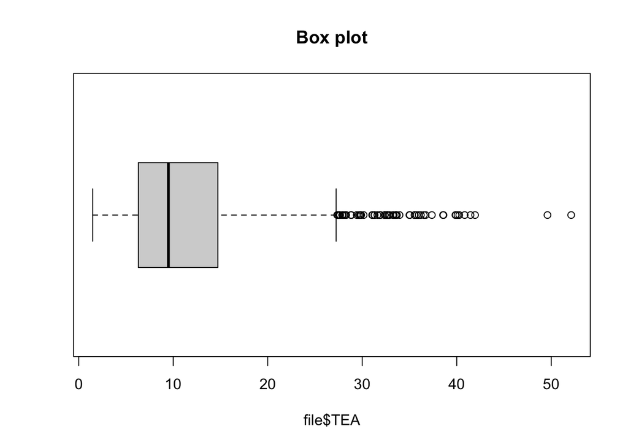

```r
boxplot(file$TEA, horizontal = TRUE, main="Box plot", xlab="file$TEA")
```

Veiem que hi ha una quantitat considerable de punts que es mostra per sobre del 1.5 vegades el rang interquartílic (marcat per la linia que es troba més a la dreta). Tots els punts que es mostren individualment, que es troben per sobre d’aquest màxim, es poden considerar candidats a ser atípics. Més explícitament, són els seguents punts que tenen un valor mes gran de 27.24:

```r
cat(boxplot.stats(file$TEA)$out, sep=' | ') #Ensenyem els punts que es troben fora del limit
```

```
## 31.05 | 32.39 | 31.31 | 32.65 | 27.96 | 29.42 | 27.87 | 29.89 | 33.58 | 28.26 | 41.94 | 31.1 | 32.9 | 49.6 | 28.3 | 32.4 | 36.71 | 36.2 | 40.84 | 27.52 | 29.62 | 27.35 | 33.53 | 27.56 | 28.83 | 31.83 | 38.55 | 29.75 | 33.23 | 33.56 | 30.15 | 28.81 | 37.37 | 35.53 | 32.79 | 27.4 | 32.61 | 39.86 | …
```

```r
extra_points <- boxplot.stats(file$TEA)$out #Els guardem en una variable
two_points <- extra_points[order(extra_points, decreasing=TRUE)][1:2] #Guardem en una variable els dos punts extres
```

Aquests son el punts que es mostren per sobre del limit. La teoria ens diu que aquests punts són candidats a ser valors atípics, pero s’ha de valorar si es coherent que ho siguin o no i si els podem descartar directament.

Primerament, veiem un conjunt de punts que es troben de manera gairebe equitativament repartida just per sobre del límit i després ens trobem dos punts aïllats al final.

Aquests dos punts finals d’aquest plot que es troben aïllats de la tendència dels altres punts. Tot i que tots els punts per sobre del limit del *box plot* es podríen veure com atípics, els punts que de veritat tenen un comportamnet diferent als altres son els dos punts de l’extrem. Proposem tractar aquests dos punt com els unics punts atípics. Anem a analitzar amb estadistica i concloure si la hipòtesi proposada es coherent.

Els dos punts aïllats tenen valor de 52.11, 49.6

Ara analitzem els diferents paràmetres i propietats del conjunt de dades de la columna TEA amb aquests punt atípics i sense aquests.

```r
original_row <- file$TEA
reduce_row <- file$TEA[!file$TEA %in% two_points] #Creem una nova variable dataFrame sense aquests punts
analysis_df <- data.frame( #Creem un dataframe amb les propietats de les dues columnes
  original_data = c(mean(original_row),median(original_row),sd(original_row),mad(original_row)),
  reduced_data = c(mean(reduce_row),median(reduce_row),sd(reduce_row),mad(reduce_row)))

rownames(analysis_df) <- c("Mitjana aritmetica", "Mediana", "Desviació estàndart","Desviació respecte la mediana")
analysis_df %>%
  kbl()%>%
  kable_styling()
```

|  | original_data | reduced_data |
| --- | --- | --- |
| Mitjana aritmetica | 11.821214 | 11.751883 |
| Mediana | 9.490000 | 9.485000 |
| Desviació estàndart | 7.724004 | 7.553145 |
| Desviació respecte la mediana | 5.685771 | 5.678358 |

Veient aquestes dades ens indica d’uns punts a tractar:

- La desviació estàndard ens indica que aquest dos punts contribueixen en un 0.1708588, pel que ens indica que aquests dos punts es troben aïllats
- La diferència en el valor de la DAM val 0.007413. Pero aquesta diferència es poc significativa ja que hi ha molts punts concentrat a la mediana.

Per tant, podem inferir d’excloure aquests dos punts i tractar-los com a punts atípics.

```r
file$TEA[file$TEA %in% two_points] <- NA #Establim aquests dos punts a NA
```

## Exercici 5

Per fer us d’aquest mètode d’imputació, hem de valorar quines de les columnes que tenim són les més útils. Per començar, hem de descartar aquelles columnes que presenten un nombre elevat de valors NA, entre aquestes la columna EMPL, MOT, FMOD i INNOV, ja que no es proporcionaran infrmació necessària.

Fent us del model de *k* veins més propers i els punts que imputem que valien NA s’han establert a:

```r
na_index <- which(is.na(file$EI)) #Busquem els index de les celes amb valor NA
imp_file <- kNN(file,
         variable="EI",
         k=5,
         dist_var= c('Code','Economy','Year','OPP','PC','FAIL','EI','TEA','OWN','FMTEA','JOB','BSER','STAT','CHOI'),
         impNA = FALSE) #Executem la funció de de trobat el valor amb els k veins mes propers

file$EI <- imp_file$EI #Establim aquests valor a la variable original
imp_file$EI[na_index] #Mostrem els punts establits per pantalla
```

```
##  [1]  8.42  4.69  6.24  4.69  3.02  8.42  8.42  8.73  6.24  8.15  8.73  6.88
## [13]  6.96  4.69 30.01  5.88 30.01  8.42 23.17  4.69  3.02 10.78 27.55  8.42
## [25]  7.44  9.05  8.73  9.05
```

## Exercici 6

Per avaluar quina relació tenen les variables OPP, PC, FAIL, EI, TEA, STAT i CHOI, ho podem fer mostrant la correlació entre variables:

```r
file_min = file[c("OPP","PC","FAIL","EI","TEA","STAT","CHOI")]%>%
  na.omit() #Agafem les columnes que ens interessen, sense contar els valors na

file_min_cor <- cor(file_min,use="complete.obs") #Mirem la seva correlació

file_min_cor %>%
  kbl()%>%
  kable_paper("hover")
```

|  | OPP | PC | FAIL | EI | TEA | STAT | CHOI |
| --- | --- | --- | --- | --- | --- | --- | --- |
| OPP | 1.0000000 | 0.6386203 | -0.0389915 | 0.4988358 | 0.5197654 | 0.4394217 | 0.4560327 |
| PC | 0.6386203 | 1.0000000 | -0.1899683 | 0.6446889 | 0.6756124 | 0.3533441 | 0.5689884 |
| FAIL | -0.0389915 | -0.1899683 | 1.0000000 | -0.1883287 | -0.1783824 | 0.0424353 | 0.0052347 |
| EI | 0.4988358 | 0.6446889 | -0.1883287 | 1.0000000 | 0.7378246 | 0.3242576 | 0.5407597 |
| TEA | 0.5197654 | 0.6756124 | -0.1783824 | 0.7378246 | 1.0000000 | 0.2241474 | 0.4394302 |
| STAT | 0.4394217 | 0.3533441 | 0.0424353 | 0.3242576 | 0.2241474 | 1.0000000 | 0.4663315 |
| CHOI | 0.4560327 | 0.5689884 | 0.0052347 | 0.5407597 | 0.4394302 | 0.4663315 | 1.0000000 |

Seguint aquesta taula de variables, podem determinar que els parells de variables que tenen més correlació entre elles. Aquestes son:

- TEA-EI amb una correlació de 0.7378246
- TEA-PC amb una correlació de 0.6756124

Les variables que menys relacionades són:

- CHOI-FAIL amb una correlació de 0.0052347
- OOP-FAIL amb una correlació de -0.0389915

## Exercici 7

Primerament, per poder fer una anàlisi de components principals, el que s’ha d’analitzar és quines són les propietats principals dels nous 7 components resultants:

```r
file_min.cov <- prcomp(file_min, center= TRUE, scale.=FALSE) #Fem anàlisi de components principals
summary(file_min.cov)$importance%>%
  kbl()%>%
  kable_paper("hover")
```

|  | PC1 | PC2 | PC3 | PC4 | PC5 | PC6 | PC7 |
| --- | --- | --- | --- | --- | --- | --- | --- |
| Standard deviation | 26.77507 | 12.30814 | 11.63214 | 9.138675 | 9.013644 | 7.946871 | 4.348811 |
| Proportion of Variance | 0.57328 | 0.12114 | 0.10820 | 0.066780 | 0.064970 | 0.050500 | 0.015120 |
| Cumulative Proportion | 0.57328 | 0.69442 | 0.80262 | 0.869410 | 0.934380 | 0.984880 | 1.000000 |

Amb aquests resultats, es mostra els 7 components principals. Es a dir, es mostren les principals dades de noves variables re-definides per capturar la màxima variabilitat amb el menor nombre de dimensions.

Per calcular quantes dimensions podem fer servir per reduir s’ha de mirar a la *Proportion of Variance* per tal d’obtenir com a minim la meitat de la mitjana de valors propis. La mitjana dels valors propis es 0.1428557. Aquesta mitjana és menor que el valor de la primera component principal, per tant, es podria reduir a una les dimensions.

Però si fem un *Scree plot* d’aquestes variables obtenim:

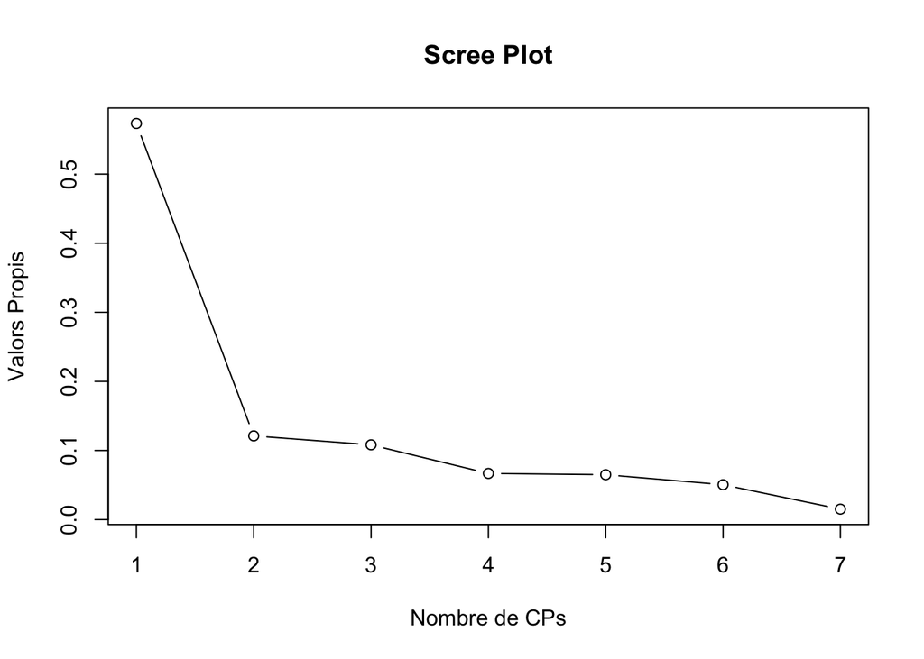

```r
summary(file_min.cov)$importance["Proportion of Variance",]%>% #Fem un plot de les variables del components principals
  plot(type="b",main="Scree Plot", xlab="Nombre de CPs", ylab="Valors Propis")
```

Entre la primera y la segona component principal veiem que es fa un ‘colze’, fent que confirmi que es pot fer una reducció a una dimensió.

Per saber quines variables orginals són més rellevants dins d’aquest component, ho mirem a traves dels vectors propis resultants quina combinació són dels vectors originals:

```r
file_min.cov$rotation[,"PC1"]%>% #Representem la taula del component 1 segons els vectors originals
  t()%>%
  as.data.frame()%>%
  kbl()%>%
  kable_styling()
```

| OPP | PC | FAIL | EI | TEA | STAT | CHOI |
| --- | --- | --- | --- | --- | --- | --- |
| -0.5312777 | -0.5004431 | 0.051964 | -0.4596134 | -0.2066606 | -0.2316802 | -0.3961965 |

On veiem que els valors que més son compresos el primer component són OPP i PC.

## Exercici 8

Guardem el resultat en un nou fitxer CSV, a la mateixa ruta que l’arxiu original

```r
write.csv(file,"gem02.csv",na="")
```